# Graphical Gaussian Process

Debangan Dey

9/7/2021

# 1 Prerequisite libraries and functions

```r
ccc = 5 # cache_indicator

rm(list=ls())
# load packages
pkgs = c("tidyverse","BRISC","igraph","gRbase","foreach","Matrix","sparseMVN","MBA","plotly","RBGL","mvtnorm","mgcv","coda","tictoc")
lapply(pkgs, require, character.only = TRUE)
#Rcpp::sourceCpp('rcpprnorm.cpp')

# Calculate multivariate normal likelihood with precision matrix K and sample covariance matrix S.
ellK <- function (K, S, n=1)
{
  value <- (n/2) * (as.numeric(determinant(K,logarithm = TRUE)$mod) - sum(rowSums(K * S)))
  return(value)
}

# Calculate Matern cross-covariance with distance u
matern <- function (u, phi, kappa)
{
  if (is.vector(u))
    names(u) <- NULL
  if (is.matrix(u))
    dimnames(u) <- list(NULL, NULL)
  uphi <- u/phi
  uphi <- ifelse(u > 0, (((2^(-(kappa - 1)))/ifelse(0, Inf,
                                                    gamma(kappa))) * (uphi^kappa) * besselK(x = uphi, nu = kappa)),
                 1)
  uphi[u > 600 * phi] <- 0
  return(uphi)
}

# Propose a new cross-correlation parameter and update the current covariance matrix.
fill.offdiagonal.one <- function(theta,m){
  clq.match <- which(unlist(lapply(clqs,function(x){all(!is.na(match(as.numeric(clqs_2[[m]]),as.numeric(x))))}))>0)
  sep.match <- which(unlist(lapply(seps,function(x){all(!is.na(match(as.numeric(clqs_2[[m]]),as.numeric(x))))}))>0)
  clq.ind <- lapply(clqs[clq.match],function(x){match(as.numeric(clqs_2[[m]]),as.numeric(x))})
  sep.ind <- lapply(seps[sep.match],function(x){match(as.numeric(clqs_2[[m]]),as.numeric(x))})

  v <- sort(clqs_2[[m]])
  sig <- sqrt(sigmahat.mat[v[1],v[1]] * sigmahat.mat[v[2],v[2]]) *( (phihat.mat[v[1],v[1]]^nuhat.mat[v[1],v[1]]) * (phihat.mat[v[2],v[2]]^nuhat.mat[v[2],v[2]])) * ((1/ phihat.mat[v[1],v[2]]) ^(2*nuhat.mat[v[1],v[2]])) * theta[m]
  sigmahat1.mat <- sigmahat.mat
  sigmahat1.mat[v[1],v[2]] <- sigmahat1.mat[v[2],v[1]] <- sig
  Stemp <-sig *matern(D,phi= 1/phihat.mat[v[1],v[2]], kappa= nuhat.mat[v[1],v[2]])

  Stemp.clq <- Slist.clq
  Stemp.sep <- Slist.sep
  Rtemp.clq <- Rlist.clq
  Rtemp.sep <- Rlist.sep

  for(i in 1:length(clq.match)){
    v <- clq.ind[[i]]
    idx=c(((v[1]-1)*n+1):(v[1]*n))
    jdx=c(((v[2]-1)*n+1):(v[2]*n))
    Stemp.clq[[clq.match[i]]][idx,jdx] <- Stemp
    Stemp.clq[[clq.match[i]]][jdx,idx] <- Stemp
    Rtemp.clq[[clq.match[i]]][v[1],v[2]] <- Rtemp.clq[[clq.match[i]]][v[2],v[1]] <- theta[m]
  }

  if(length(sep.match)>0){
    for(i in 1:length(sep.match)){
      v <- sep.ind[[i]]
      idx=c(((v[1]-1)*n+1):(v[1]*n))
      jdx=c(((v[2]-1)*n+1):(v[2]*n))
      Stemp.sep[[sep.match[i]]][idx,jdx] <- Stemp
      Stemp.sep[[sep.match[i]]][jdx,idx] <- Stemp
      Rtemp.sep[[sep.match[i]]][v[1],v[2]] <- Rtemp.sep[[sep.match[i]]][v[2],v[1]] <- theta[m]
    }
  }
  return(list(Slc=Stemp.clq,Sls=Stemp.sep,Rlc=Rtemp.clq,Rls=Rtemp.sep,sigmahat=sigmahat1.mat))
}

# Calculate new likelihood based on the proposed cross-correlation parameter
comp.lik.oneedge <- function(t,S.clq,S.sep,R.clq,R.sep){
  clq.match <- clqmatchedge[[t]]
  sep.match <- sepmatchedge[[t]]
  y=unlist(wl)
  n=length(y)/q
  m = 1

  k.store <- list()
  k.sep.store <- list()

  max.clq.length <- max(sapply(clqs[clq.match],length))

  lclq <- lsep <- NULL

  if(max.clq.length > 2){
    pdind.clq <- unlist(lapply(clq.match,function(x){
      slanczos(R.clq[[x]],k=1,kl=1)$val[2]}))

    pdind.sep <- NULL
    if(length(sep.match)>0){
      pdind.sep <- unlist(lapply(sep.match,function(x){
        slanczos(R.sep[[x]],k=1,kl=1)$val[2]}))}

    pdind <- c(pdind.clq,pdind.sep)
  } else {
    pdind <- 1}

  if(all(pdind>0)){
    lclq <- unlist(lapply(clq.match,function(l){
      kdummy <- rcppeigen_invert_matrix(S.clq[[l]])
      Sy=Sy.clq.list[[l]]
      value <- ellK(K=kdummy, S=Sy, n=1)
      value}))

    if(length(sep.match)>0){
      lsep <- unlist(lapply(sep.match,function(l){
        kdummy <- rcppeigen_invert_matrix(S.sep[[l]])
        Sy=Sy.sep.list[[l]]
        value <- ellK(K=kdummy, S=Sy, n=1)
        value}))
    } else {
      lsep =0
    }
    val <- sum(lclq) - sum(lsep)
  } else {
    val <- -10^26
  }
  return(list(lik=-val,lclq=lclq,lsep=lsep))
}

# Calculate likelihood of multivariate normal which respects a decomposable graph with clique = clqs, separator = seps
decomp_ips_par <- function(S,q,clqs=clqs, seps=seps){
  k.store <- list()
  k.sep.store <- list()
  n <- ncol(S)/q
  S <- (S + t(S))/2

  kclq <- foreach(l=1:length(clqs),.combine='+',.export=c("clqs","seps"),.packages = "FastGP") %do%{
    varsub <- clqs[[l]]
    sub <- unlist(lapply(varsub,function(x){c(((x-1)*n+1):(x*n))}))
    kdummy <- matrix(0,ncol=n*q,nrow=n*q)
    kdummy[sub,sub]=rcppeigen_invert_matrix(S[sub,sub])
    kdummy
  }

  ksep <- foreach(l=2:length(seps),.combine='+',.export=c("clqs","seps"),.packages = "FastGP") %do%
  {
    varsub <- seps[[l]]
    sub <- unlist(lapply(varsub,function(x){c(((x-1)*n+1):(x*n))}))
    kdummy <- matrix(0,ncol=n*q,nrow=n*q)
    kdummy[sub,sub] <- rcppeigen_invert_matrix(S[sub,sub])
    kdummy
  }
  K <- kclq - ksep
  return((K+t(K))/2)
}

simp.mat <- function(A){
  d <- dim(A)
  Am <- matrix(nrow=d[1],ncol=d[2]*d[3])
  for(i in 1:d[1]){
    Am[i,] <- as.numeric(t(A[i,,]))
  }
  return(Am)
}
```

Here we also load a Rcpp function for faster simulation from multivariate normal distribution.

```cpp
#include <RcppArmadillo.h>
// [[Rcpp::depends(RcppArmadillo)]]

using namespace Rcpp;

// [[Rcpp::export]]
arma::mat mvrnormArma(int n, arma::vec mu, arma::mat sigma) {
  int ncols = sigma.n_cols;
  arma::mat Y = arma::randn(n, ncols);
  return arma::repmat(mu, 1, n).t() + Y * arma::chol(sigma);
}
```

# 2 Introduction

Abundant multivariate spatial data from the natural and environmental sciences demands research on the joint distribution of multiple spatially dependent variables (Wackernagel (2013),Cressie and Wikle (2011),Banerjee, Carlin, and Gelfand (2014)). Here, our goal is to estimate associations over spatial locations for each variable and those among the variables.

In this document, we will present an example of a simulated multivariate spatial data and how we can use Graphical Gaussian processes (GGP) (Dey, Datta, and Banerjee (2021)) to model the data. First, we’ll introduce the general multivariate spatial model, and then we will introduce a variable graph and how to simulate a Graphical Gaussian process (Matérn) for that variable graph. Next, we will lay out the estimation steps of GGP parameters and how the estimated parameters compare against the truth.

# 3 Model

Let $y(s)$ denote a $q\times 1$ vector of spatially-indexed dependent outcomes for any location $s \in \mathcal D \subset \mathbb{R}^d$ with typically $d=2$ or $3$. On our spatial domain $\mathcal D$, a multivariate spatial regression model provides a marginal spatial regression model for each outcome as follows:
$$\begin{equation}
y_i(s) = x_i(s)^{T}\beta_i + w_i(s) + \epsilon_i(s)\;,\quad i=1,2,\ldots,q,\; s \in \mathcal D
\tag{3.1}
\end{equation}$$
where $y_i(s)$ is the $i$-th element of $y(s)$, $x_i(s)$ is a $p_i\times 1$ vector of predictors, $\beta_i$ is the $p_i\times 1$ vector of slopes, $w_i(s)$ is a spatially correlated process and $\epsilon_i(s) \stackrel{ind}{\sim} N(0,\tau^2_i)$ is the random error in outcome $i$. We usually assume that $\epsilon_i(s)$ are independent across $i$, whereas $w(s)=(w_1(s), w_2(s),\ldots, w_q(s))^T$ is a zero-centred multivariate Gaussian process (GP) with a zero mean and a cross-covariance function that introduces dependency across space and among the $q$ variables. Let $\mathcal S_i$ represent the collection of places where the $i-$th variable was observed. The reference set of locations for our approach is $\mathcal L = \cup_i\mathcal S_i$.

The definition of $w(s)$ as the $q \times 1$ multivariate graphical Matérn GP (Dey, Datta, and Banerjee (2021)) with respect to a decomposable variable graph ${\mathcal G}_{\mathcal V}$ yields the distribution of each $w_i$. The marginal parameters for each component Matérn process $w_i(\cdot)$ are denoted by $\{\phi_{ii}, \sigma_{ii} | i = 1.\ldots,q\}$.

It is sufficient to limit the intra-site covariance matrix $\Sigma=(\sigma_{ij})$ to be of the following form to assure a valid multivariate Matérn cross-covariance function (Theorem 1 of Apanasovich, Genton, and Sun (2012)) -

$$\begin{equation}
\begin{array}{cc}
\nu_{ij} =& \frac 12 (\nu_{ii} + \nu_{jj}) + \Delta_A (1 - A_{ij}) \mbox{ where } \Delta_A \geq 0, A=(A_{ij}) \mbox{ for all } i \geq 0, A_{ii}=1 \\
\sum_{i,j} c_ic_j\phi_{ij} \leq 0 &\mbox{ is a conditionally non-negative definite matrix } \\
\sigma_{ij} =& b_{ij} \frac{\Gamma(\frac 12 (\nu_{ii}+\nu_{jj} + d))\Gamma(\nu_{ij})}{\phi_{ij}^{2\Delta_A+\nu_{ii}+\nu_{jj}}\Gamma(\nu_{ij} + \frac d2)} \mbox{ where } \Delta_A \geq 0, \mbox{ and } B=(b_{ij}) > 0, \mbox{ i.e., is p.d.}
\end{array}
\tag{3.2}
\end{equation}$$
This is equal to $\Sigma = (B \odot (\gamma_{ij}))$, where $\gamma_{ij}$’s are constants collecting the components in (3.2) involving just $\nu_{ij}$’s and $\phi_{ij}$’s, and $\odot$ indicates the Hadamard (element-wise) product.

In the following example, we’ll assume $\Delta_A=0, \nu_{ij} = \frac{\nu_{ii}+\nu_{jj}}{2}$, $\phi_{ij}^2 = \frac{\phi_{ii}^2 + \phi_{jj}^2}{2}$. The constraints in (3.2) simplifies to -

$$\begin{equation}
\begin{array}{cc}
\sigma_{ij} =& (\sigma_{ii} \sigma_{jj})^{\frac{1}{2}} * \frac{\phi_{ii}^{\nu_{ii}}\phi_{jj}^{\nu_{jj}}}{\phi_{ij}^{\nu_{ij}}} \frac{\Gamma(\nu_{ij})}{\Gamma(\nu_{ii})^{\frac 12} \Gamma(\nu_{ij})^{\frac 12}} r_{ij} \mbox{ where }, \mbox{ and } R=(r_{ij}) > 0, \mbox{ i.e., is p.d.}
\end{array}
\tag{3.3}
\end{equation}$$

We also take $\nu_{ii} = \nu_{jj} = 0.5$ in our case and hence, we only need to estimate the marginal scale ($\phi_{ii}$) and variance parameters ($\sigma_{ii}$) and cross-correlation parameters $r_{ij}$. We also assume variable graph (${\mathcal G}_{\mathcal V}$) to be decomposable.

# 4 Simulation

As a first step of simulation, we need to fix a decomposable variable graph (${\mathcal G}_{\mathcal V}$). Depending on the perfect ordering of cliques in the graph, the density function of the full process can be factorized. Using this property, we can calculate the variance-covarinace matrix of the GGP and use it to simulate observation from a multivariate GGP.

## 4.1 Decomposable variable graph

If $\mathcal G_\mathcal V$ is decomposable, it has a perfect clique sequence $\{K_1,K_2,\cdots,K_p\}$ with separators $\{S_2,\ldots,S_m\}$, and $w(\mathcal L)$’s joint density may be factorized as follows.
$$\begin{equation}
f_M(w(\mathcal L)) = \frac{\Pi_{m=1}^{p} f_C(w_{K_m}( \mathcal L))}{\Pi_{m=2}^{p} f_C(w_{S_m}( \mathcal L))}\;,
\tag{4.1}
\end{equation}$$
where $S_m=F_{m-1} \cap K_m$ and $F_{m-1}= K_1 \cup \cdots \cup K_{m-1}$, and $f_A$ denotes the the density of a GP over $\mathcal L$ with covariance function $A$ for $A \in \{M,C\}$.

Here, we assume we have $10$ variables with each being observed at $250$ locations uniformly chosen from the $(0,1) \times (0,1)$ square. We assume the variable graph to be as follows -

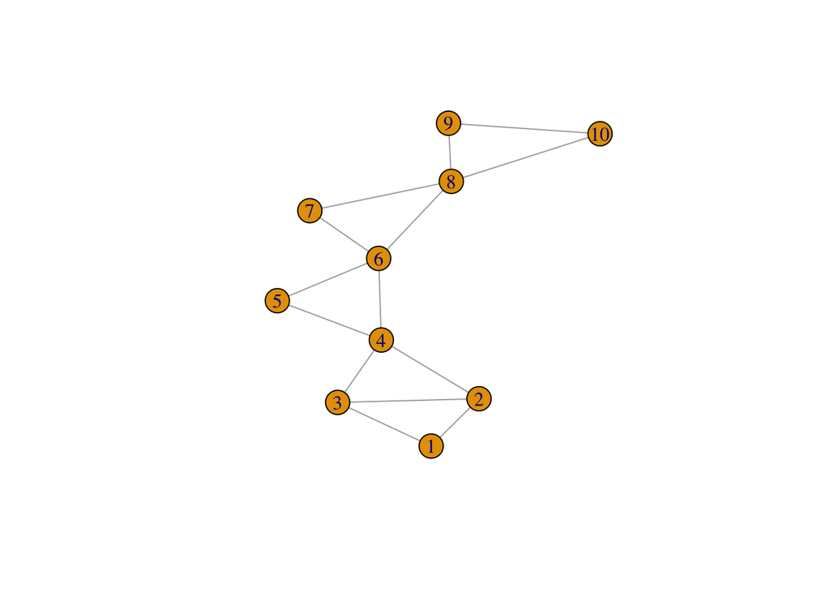

```r
ccc = 5 # cache_indicator
q=10
# Fix graph and plot it
G_V <- make_graph(c(1,2,2,3,1,3,2,4,3,4,4,5,5,6,4,6,6,7,7,8,6,8,8,9,9,10,8,10),directed=FALSE)
plot(G_V)
```

```r
A_V <- as.matrix(as_adjacency_matrix(G_V))
```

We calculate the perfect ordering of the cliques of the graph above and list the cliques and separators below. To visualize the decomposition, we also plot the junction tree (definition below) of the graph -

The **junction graph** $G$ of a decomposable graph $\mathcal G_\mathcal V$ is a complete graph with the cliques of $\mathcal G_\mathcal V$ as its nodes. Every edge in the junction graph is denoted as a link, which is also the intersection of the two cliques, and can be empty. A **spanning tree** of a graph is defined as a subgraph comprising all the vertices of the original graph and is a tree (acyclic graph). If a spanning tree $J$ of the junction graph of $G$ satisfies the following property: for any two cliques $C$ and $D$ of the graph, every node in the unique path between $C$ and $D$ in the tree contains $C \cap D$. Then $J$ is called the **junction tree** for the graph $\mathcal G_\mathcal V$. Here, the junction tree of the graph has the perfectly ordered cliques as its nodes and the separators denoted as edges.

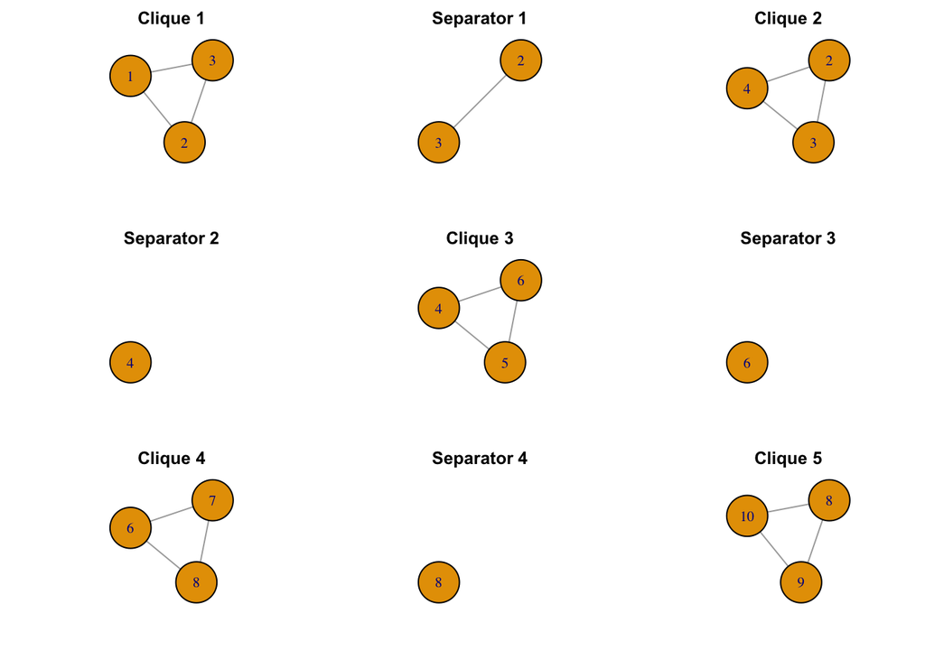

```r
ccc = 5 # cache_indicator
# list cliques and separators
diag(A_V) <- 0
Dord <- rip(as(A_V,"graphNEL"))
clqs <- lapply(Dord$cliques,as.integer)
clqs <- lapply(clqs,sort)
max.clq.length <- max(sapply(clqs,function(x){length(x)}))
seps <- lapply(Dord$separators,as.integer)
seps <- lapply(seps,sort)
b <- lapply(clqs,function(x){x<-sort(x);c <- combn(x,2);c})
b <- reduce(b,cbind) %>% unique(MARGIN=2)
clqs_2 <- split(b,rep(1:ncol(b), each = nrow(b)))
max.clq.length <- max(sapply(clqs,length))

# Plot cliques in sequence
par(mfrow=c(3,3),mar=c(3,4,2,2))
plot(induced_subgraph(G_V,clqs[[1]]),vertex.label = clqs[[1]], vertex.size=100, main="Clique 1")
plot(induced_subgraph(G_V,seps[[2]]),vertex.label = seps[[2]],label.cex=10, vertex.size=100, main="Separator 1")
plot(induced_subgraph(G_V,clqs[[2]]),vertex.label = clqs[[2]],label.cex=3,vertex.size=100, main="Clique 2")
plot(induced_subgraph(G_V,seps[[3]]),vertex.label = seps[[3]],label.cex=3,vertex.size=100, main="Separator 2")
plot(induced_subgraph(G_V,clqs[[3]]),vertex.label = clqs[[3]],label.cex=3,vertex.size=100, main="Clique 3")
plot(induced_subgraph(G_V,seps[[4]]),vertex.label = seps[[4]],label.cex=3,vertex.size=100, main="Separator 3")
plot(induced_subgraph(G_V,clqs[[4]]),vertex.label = clqs[[4]],label.cex=3,vertex.size=100, main="Clique 4")
plot(induced_subgraph(G_V,seps[[5]]),vertex.label = seps[[5]],label.cex=3,vertex.size=100, main="Separator 4")
plot(induced_subgraph(G_V,clqs[[5]]),vertex.label = clqs[[5]],label.cex=3, vertex.size=100, main="Clique 5")
```

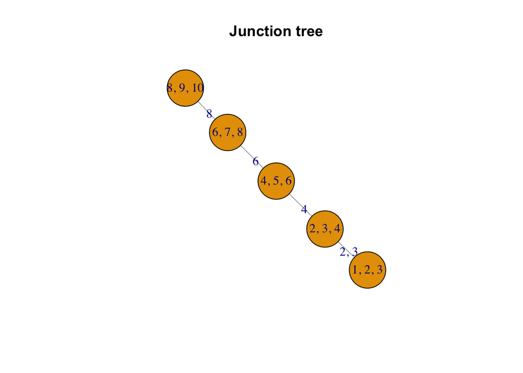

```r
ccc = 5 # cache_indicator
plot(make_tree(length(clqs),1,mode="undirected"), vertex.label=sapply(clqs,function(x){paste(x,sep=", ", collapse=", ")}), vertex.size=40, edge.label = sapply(seps[-1],function(x){paste(x,sep=", ", collapse=", ")}), title="Junction tree", label.cex=5, main="Junction tree")
```

Hence, in this case, the likelihood of the decomposable GGP would be as follows -
$$\begin{equation}
f_M(w(\mathcal L)) = \frac{f_C(w_{(1,2,3)}(\mathcal L)) f_C(w_{(2,3,4)}(\mathcal L)) f_C(w_{(4,5,6)}(\mathcal L)) f_C(w_{(6,7,8)}(\mathcal L)) f_C(w_{(8,9,10)}(\mathcal L))}{f_C(w_{(2,3)}(\mathcal L)) f_C(w_{(4)}(\mathcal L)) f_C(w_{(6)}(\mathcal L)) f_C(w_{(8)}(\mathcal L))}\;,
\tag{4.2}
\end{equation}$$

## 4.2 Simulating latent GGP

First we fix the marginal and cross-covariance parameters of the process.

```r
ccc = 5 # cache_indicator
set.seed(23)
# number of locations
n=250
# number of variables
q = 10
# Generating locations on (0,1) * (0,1) plane and calculating distance matrix
coords <- cbind(runif(n,0,1),runif(n,0,1))
D <-  as.matrix(dist(coords))

# Fixing multivariate Matern parameters
D_B=0
R <- matrix(runif(q^2,-1,1), ncol=q)
B <- matrix(rnorm(q^2,0,2), ncol=q)
r0 <- runif(q-1,0.1,0.7)
R_B <- cov2cor(B %*% t(B))
nu.mat = matrix(0.5, ncol=q, nrow= q)
phi.diag= sample(seq(1,5,length.out = q))
sigma.diag= sample(seq(5,1,length.out = q))
phi.mat = diag(phi.diag)
# Creating scale matrix
for(i in 1:(q-1)){
  for (j in (i+1): q){
    phi.mat[i,j]= sqrt((phi.mat[i,i]^2 + phi.mat[j,j]^2)/2) + D_B*(1-R_B[i,j])
    phi.mat[j,i] = phi.mat[i,j]
  }
}
# Creating sigma matrix
sigma.mat=diag(sigma.diag)
# Cross-correlation parameters
b <- cov2cor(R %*% t(R))
for(i in 1:(q-1)){
  for (j in (i+1): q){
    sigma.mat[i,j]= sqrt(sigma.mat[i,i] * sigma.mat[j,j]) *( (phi.mat[i,i]^nu.mat[i,i]) * (phi.mat[j,j]^nu.mat[j,j])) * ((1/ phi.mat[i,j]) ^(2*nu.mat[i,j])) * b[i,j]
    sigma.mat[j,i] = sigma.mat[i,j]
  }
}

# Constructing cross-covariance matrix for the process
SIGMA <- matrix(ncol=n*q, nrow=n*q)

for (i in 1:q){
  for(j in i:q){
    idx=c(((i-1)*n+1):(i*n))
    jdx=c(((j-1)*n+1):(j*n))
    SIGMA[idx,jdx] = sigma.mat[i,j]*matern(D,phi= 1/phi.mat[i,j], kappa= nu.mat[i,j])
    SIGMA[jdx,idx] = SIGMA[idx,jdx]
  }
}
# Create Cholesky decomposition
S <- SIGMA
```

Now, the precision matrix of the GGP $w(\mathcal L)$ satisfies (Lemma 5.5 of Lauritzen (1996))
$$\begin{equation}
M(\mathcal L,\mathcal L)^{-1} = \sum_{m=1}^{p} [{C}_{[K_m \boxtimes \mathcal{G_L}]}^{-1}]^{\mathcal V \times \mathcal L} - \sum_{m=2}^{p} [{C}_{[S_m \boxtimes \mathcal{G_L}]}^{-1}] ^{\mathcal V \times \mathcal L}\;, %= \sum_{m=1}^{p} [{M}_{[K_m \boxtimes \mathcal{G_L}]}^{-1}] ^\mathcal V - \sum_{m=2}^{p} [{M}_{[S_m \boxtimes \mathcal{G_L}]}^{-1}] ^\mathcal V\;
\tag{4.3}
\end{equation}$$

The (4.3) and (4.1) shows that inverting the full cross-covariance matrix only requires inverting the clique and separator specific covariance matrices. Hence, the computational complexity for calculating likelihood of a multivariate GGP boils down to $O(n^3 c^3)$ (here, $O(250^3 * 27)$) where $c= 3$ is the maximum size of a clique in the perfect clique ordering of the graph. On the contrary, the likelihood of a full GGP would need $O(n^3 q^3)$ complexity, i.e. $O(250^3 * 1000)$ in our case.

We use the (4.3) to calculate the covariance of the latent GGP and we use it to simulate the latent process.

```r
ccc = 5 # cache_indicator
# Calculate GGP precision matrix
K0 = decomp_ips_par(S, 10, clqs=clqs, seps = seps)
B <- as((K0+t(K0))/2, "sparseMatrix")
Lk <- Cholesky(B, LDL=FALSE)

rm(K0)
rm(B)
w0 <- rmvn.sparse(1,mu=rep(0,n*q),CH=Lk)
```

## 4.3 Simulating multivariate spatial outcome

Now we use (3.1) to simulate our multivariate outcome $y_i(.), i= 1, \cdots, 10$. In order to do that, we fix some covariates $x_i(\cdot)$ and simulate error process $\eps_i(.)$ independently from $N(0,\tau^2_{ii})$. We take $\tau_{ii}^2=\tau^2=0.25$ for all $i$.

```r
ccc = 5 # cache_indicator
# Covariate
X <- rnorm(n*q,0,2)
# Regression coefficient for covariate
beta0 <- runif(q,-2,2)
# Error variance
tausq0 <- rep(0.25,q)
# Generate error
e0 <- rnorm(n*q,0,sqrt(tausq0[1]))
Y <- as.numeric(t(X) %*% diag(rep(beta0,each=n)) + w0 + e0)
X <- as.numeric(X)
w.data <- matrix(w0,ncol=q)
Y.data <- matrix(Y, ncol=q)
X.data <- matrix(X, ncol=q)
```

For analyzing the prediction accuracy of our method, we randomly pick $20\%$ of the locations for each outcome variable and consider them missing. We will only be working with the training set to fit the model and judge our prediction accuracy on the test set.

```r
ccc = 5 # cache_indicator
# Fixing test set location for each variable
test.prop <- 0.2
test.sample <- list()
exc <- list()
for(k in 1:q){
  test.sample[[k]] <- sort(sample(1:n,size=n*test.prop))
  exc[[k]] <- test.sample[[k]] + (k-1)*n
}

# Splitting into train and test data
Y.train <- sapply(1:q,function(x){Y.data[,x][-test.sample[[x]]]},simplify = TRUE)
X.train <- sapply(1:q,function(x){X.data[,x][-test.sample[[x]]]},simplify = TRUE)
X.test <- sapply(1:q,function(x){X.data[,x][test.sample[[x]]]},simplify = TRUE)
Y.test <- sapply(1:q,function(x){Y.data[,x][test.sample[[x]]]},simplify = TRUE)
```

```r
#print("Surface plots for latent processes")
# surf_w=list()
# for(i in 1:q){
#   surf_w[[i]] <- mba.surf(cbind(coords,w.data[,i]), no.X=200, no.Y=200, h=5, m=2, extend=F, b.box=c(min(coords[,1]),max(coords[,1]),min(coords[,2]),max(coords[,2])))$xyz.est
# }
# fig <- htmltools::tagList()
# for(i in 1:q){
# fig[[i]] <- plot_ly(x = surf_w[[i]]$x, y = surf_w[[i]]$y, z=surf_w[[i]]$z, type = "surface") %>% layout(title=paste("Surface plots for latent process for variable", i))
# }
# fig
```

```r
# #"Surface plots for observed outcome")
# surf_Y=list()
# for(i in 1:q){
#   surf_Y[[i]] <- mba.surf(cbind(coords,Y.data[,i]), no.X=200, no.Y=200, h=5, m=2, extend=F, b.box=c(min(coords[,1]),max(coords[,1]),min(coords[,2]),max(coords[,2])))$xyz.est
# }
# fig <- htmltools::tagList()
# for(i in 1:q){
# fig[[i]] <- plot_ly(x = surf_Y[[i]]$x, y = surf_Y[[i]]$y, z=surf_Y[[i]]$z, type = "surface") %>% layout(title=paste("Surface plots for latent process for variable", i))
# }
# fig
```

# 5 Data analysis

The analysis of our simulated data can be broken down in the following steps -

## 5.1 Marginal parameter estimation

1. We first estimate the marginal process parameters using **BRISC** package in R. We estimate scale ($\phi_{ii}$) and variance ($\sigma_{ii}$) parameters. We fix the marginal smoothness ($\nu_ii$) and cross-smoothness ($\nu_{ij}$) parameters at $0.5$.
2. Same as the true cross-covariance, we calculate the cross-scale parameters as: $\phi_{ij}= \sqrt{\frac{\phi_{ii}^2 + \phi_{jj}^2}{2}}$.
3. We estiamte the marginal regression coefficients ($\beta_i$).
4. We estimate the marginal error varicne ($\tau_{ii}^2$).

```r
ccc = 5 # cache_indicator
# n: number of locations
# q: number of variables
# m: number of nearest neighbors considered
# coords: a n*2 coordinate matrix of locations
# test.sample: A list of length q storing the missing (test) locations for each variable
# X.train: The covariate matrix (assuming one covariate here)
# Y.train: Observations (n*q matrix)
# Fitting the model
# Estimating marginal materns with BRISC
M <- list()
for(i in 1:q){
  M[[i]] <- BRISC_estimation(coords[-test.sample[[i]],], x=as.matrix((X.train[,i])), y=(Y.train[,i]), n.neighbors = 15, cov.model="exponential")
}

# Fix marginal smoothness as 0.5
nuhat.mat = matrix(0.5, ncol=q, nrow= q)

# Get marginal scale parameters and calculate cross-scale parameters
phihat.diag=  unlist(lapply(M,function(x){x$Theta[3]}))
phihat.mat = diag(phihat.diag)

for(i in 1:(q-1)){
  for (j in (i+1): q){
    phihat.mat[i,j]= sqrt((phihat.mat[i,i]^2 + phihat.mat[j,j]^2)/2)
    phihat.mat[j,i] = phihat.mat[i,j]
  }
}
# Regression coefficient
beta <- unlist(lapply(M,function(x){x$Beta}))
# Error variance
tausq= unlist(lapply(M,function(x){x$Theta[2]}))
```

## 5.2 Initialize Gibbs sampling

1. **Process the variable graph**:

First, we color the nodes of the variable graph. This will allow us to simulate the latent processes belonging to the same color in parallel.

We also construct a new graph $\mathcal G_E(\mathcal G_V)=(E_\mathcal V,E^*)$ which denotes this graph on the set of edges $E_\mathcal V$, i.e., there is an edge $((i,j),(i',j'))$ in this new graph $\mathcal G_E(\mathcal G_V)$ if $\{i,i',j,j'\}$ are in some clique $K$ of $\mathcal G_V$. This allows us to facilitate parallel update of cross-correlation parameters corresponding to edges in the same color.

These two procedures are examples of chromatic Gibbs sampling.

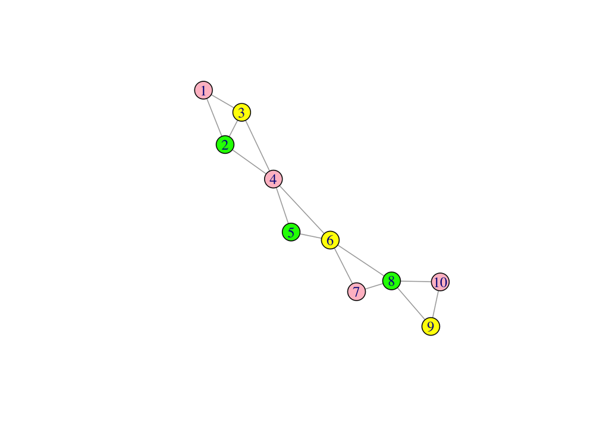

```r
ccc = 5 # cache_indicator
# Node coloring
g_v <- graph_from_adjacency_matrix(A_V,mode="undirected")
g_V <- as(A_V[as.numeric(max_cardinality(g_v)$alpha),as.numeric(max_cardinality(g_v)$alpha)],"graphNEL")
coloring <- as.numeric(sequential.vertex.coloring(g_V)$color[max_cardinality(g_v)$alpham])
plot(g_v, vertex.color=c("Pink","Green","Yellow"))
```

```r
# Get cliques and separators
diag(A_V) <- 0
Dord <- rip(as(A_V,"graphNEL"))
clqs <- lapply(Dord$cliques,as.integer)
clqs <- lapply(clqs,sort)
max.clq.length <- max(sapply(clqs,function(x){length(x)}))
seps <- lapply(Dord$separators,as.integer)
seps <- lapply(seps,sort)
bb <- lapply(clqs,function(x){x<-sort(x);c <- combn(x,2);c})
bb <- reduce(bb,cbind) %>% unique(MARGIN=2)
clqs_2 <- split(bb,rep(1:ncol(bb), each = nrow(bb)))
true <- unlist(lapply(clqs_2,function(x){b[x[1],x[2]]}))
max.clq.length <- max(sapply(clqs,length))

# Coloring for edges
ne <- length(clqs_2)
A_E <- matrix(0,nrow=ne, ncol=ne)
if(ne >1){
  for(i in 1:(ne-1)){
    for(j in (i+1):ne){
      e <- sort(union(clqs_2[[i]], clqs_2[[j]]))
      A_E[i,j] <- any(sapply(clqs, function(x){setequal(intersect(x,e),e)}))
      A_E[j,i] <- A_E[i,j]
    }
  }
  g_e <- graph_from_adjacency_matrix(A_E,mode="undirected")
  g_E <- as(A_E[as.numeric(max_cardinality(g_e)$alpha),as.numeric(max_cardinality(g_e)$alpha)],"graphNEL")
  coloring_e <- as.numeric(sequential.vertex.coloring(g_E)$color[max_cardinality(g_e)$alpham])
} else{
  coloring_e <- 0
}
```

2.**Calculate initial cross-covariance matrix**: Start with an initial cross-correlation matrix. We Take a convex combination: $0.5*diag(q) + 0.5*cor(Y.train)$. Then we use this initial cross-correlation parameters and estimated marginal parameters to store the cross covariance matrices for cliques and separators only.

The largest matrix we need to store is of size $nq_c \times nq_c$ matrix where $q_c$ is the size of maximum clique or separator)

```r
ccc = 5 # cache_indicator
# Initial cross-covariance matrix
rho=0.5
R_V= (1-rho)*diag(q) + rho*cor(Y.train)
R <- R_V
# Initial cross-correlation parameters
theta = unlist(lapply(clqs_2,function(x){R_V[x[1],x[2]]}))
sigmahat.diag=unlist(lapply(M,function(x){x$Theta[1]}))
sigmahat.mat=diag(sigmahat.diag)
for(i in 1:(q-1)){
  for (j in (i+1): q){
    sigmahat.mat[i,j]=  sqrt(sigmahat.mat[i,i] * sigmahat.mat[j,j]) *( (phihat.mat[i,i]^nuhat.mat[i,i]) * (phihat.mat[j,j]^nuhat.mat[j,j])) * ((1/ phihat.mat[i,j]) ^(2*nuhat.mat[i,j])) * R_V[i,j]
    sigmahat.mat[j,i] = sigmahat.mat[i,j]
  }
}

# Store clique and separator cross-covariances as a list
Slist.clq <- Slist.sep <- list()
Rlist.clq <- Rlist.sep <- list()

for(k in 1:length(clqs)){
  comp <- sort(clqs[[k]])
  pc <- length(clqs[[k]])
  sigmahat.sub <- sigmahat.mat[comp,comp]
  phihat.sub <- phihat.mat[comp,comp]
  nu.sub <- nu.mat[comp,comp]
  Stemp <- matrix(nrow=n*pc,ncol=n*pc)
  for (i in 1:pc){
    for(j in i:pc){
      idx=c(((i-1)*n+1):(i*n))
      jdx=c(((j-1)*n+1):(j*n))
      Stemp[idx,jdx] = sigmahat.sub[i,j]*matern(D,phi= 1/phihat.sub[i,j], kappa= nu.sub[i,j])
      Stemp[jdx,idx] = Stemp[idx,jdx]
    }
  }
  Slist.clq[[k]] <- Stemp
  Rlist.clq[[k]] <- R[comp,comp]
  rm(Stemp)
}

for(k in 2:length(seps)){
  comp <- sort(seps[[k]])
  pc <- length(seps[[k]])
  sigmahat.sub <- as.matrix(sigmahat.mat[comp,comp])
  phihat.sub <- as.matrix(phihat.mat[comp,comp])
  nu.sub <- as.matrix(nu.mat[comp,comp])
  Stemp <- matrix(nrow=n*pc,ncol=n*pc)
  for (i in 1:pc){
    for(j in i:pc){
      idx=c(((i-1)*n+1):(i*n))
      jdx=c(((j-1)*n+1):(j*n))
      Stemp[idx,jdx] = sigmahat.sub[i,j]*matern(D,phi= 1/phihat.sub[i,j], kappa= nu.sub[i,j])
      Stemp[jdx,idx] = Stemp[idx,jdx]
    }
  }
  Slist.sep[[k]] <- Stemp
  Rlist.sep[[k]] <- R[comp,comp]
  rm(Stemp)
}
clqmatchedge <- sepmatchedge <- list()
for(t in 1:length(clqs_2)){
  clqmatchedge[[t]] <- which(unlist(lapply(clqs,function(x){all(!is.na(match(as.numeric(clqs_2[[t]]),as.numeric(x))))}))>0)
  sepmatchedge[[t]] <- which(unlist(lapply(seps,function(x){all(!is.na(match(as.numeric(clqs_2[[t]]),as.numeric(x))))}))>0)
}

clqmatchvar <- sepmatchvar <- list()
for(t in 1:q){
  clqmatchvar[[t]] <- which(unlist(lapply(clqs,function(x){all(!is.na(match(as.numeric(t),as.numeric(x))))}))>0)
  sepmatchvar[[t]] <- which(unlist(lapply(seps,function(x){all(!is.na(match(as.numeric(t),as.numeric(x))))}))>0)
}

# Initial latent spatial process parameters
Yl <- list()
Xl <- list()
wl <- list()
for(i in 1:q){
  Yl[[i]] = Y.train[,i]
  Xl[[i]] = X.train[,i]
  wl[[i]] = numeric(n)
  cmatch <- clqmatchvar[[i]][1]
  imatch <- which(clqs[[cmatch[1]]]==i)
  im <- c(((imatch-1)*n+1):(imatch*n))
  wtemp <- as.numeric(rmvnorm(1,sigma=Slist.clq[[cmatch[1]]][im,im]))
  wl[[i]][-test.sample[[i]]] = wtemp[-test.sample[[i]]]
  wl[[i]][test.sample[[i]]] = wtemp[test.sample[[i]]]
}

w = unlist(wl)
```

## 5.3 Gibbs sampling

### 5.3.1 Sampling latent processes

To update the latent random effects $w$, let $\mathcal L=\{s_1,\ldots,s_n\}$ and $o_i=\mbox{diag}(I(s_1 \in \mathcal S_i), \ldots, I(s_n \in \mathcal S_i))$ denote the vector of missing observations for the $i$-th outcome. With $X_{i}(\mathcal L) = (x_i(s_1),\ldots,x_i(s_n))^T$, $y_i(\mathcal L)$ and $w_i(\mathcal L)$ defined similarly, we obtain
$$\begin{equation*}
\begin{split}
p(w_i(\mathcal L) | \cdot) & \sim N\left(\mathcal M_i^{-1}\mu_i, \mathcal M_i^{-1}\right)\;, \mbox{ where } \\
\mathcal M_i & =\frac{1}{\tau_i^2}\mbox{diag}(o_i) + \sum_{K \ni i}M_{\{i\} \times \mathcal L|(K\setminus \{i\}) \times \mathcal L}^{-1} - \sum_{S \ni i}M^{-1}_{\{i\} \times \mathcal L|(S\setminus \{i\}) \times \mathcal L}\;, \\
\mu_i &= \frac{(y_i(\mathcal L) - x_i(\mathcal L)^{T}\beta_i)\odot o_i}{\tau_i^2} + \\
& \qquad \sum_{K \ni i} T_{i}(K) w({(K\setminus \{i\}) \times \mathcal L}) - \sum_{S \ni i} T_i(S) w({(S\setminus \{i\}) \times \mathcal L})\;, \\
T_{i}(A) &= M_{\{i\} \times \mathcal L|(A\setminus \{i\}) \times \mathcal L}^{-1} M_{\{i\} \times \mathcal L,(A\setminus \{i\}) \times \mathcal L}M_{(A\setminus \{i\}) \times \mathcal L}^{-1}, \mbox{ for } A \in \{K,S\}.\\
% U_i(S) &= M_{\{i\} \times \mathcal L|(S\setminus \{i\}) \times \mathcal L}^{-1} M_{(S\setminus \{i\}) \times \mathcal L,\{i\} \times \mathcal L}M_{(S\setminus \{i\}) \times \mathcal L}^{-1}.
\end{split}\label{eqn: gibbs-sam-latent}
\end{equation*}$$

### 5.3.2 Sampling cross-correlation parameters

Requires only checking positive-definiteness of the clique-specific cross-covariance matrix and inverting it. The largest matrix inversion across all these updates is of the order $nc \times nc$, corresponding to the largest clique. The largest matrix that needs storing is also of dimension $nc \times nc$. These result in appreciable reduction of computations from any multivariate Mat'ern model that involves $nq \times nq$ matrices and positive-definiteness checks for $q \times q$ matrices at every iteration.

1. For every correlation parameter corresponding to edges in the current graph, we draw a new correlation value from the proposal distribution.
2. We accept or reject the proposal based on the Metropolis-Hastings acceptance probability.

```r
ccc = 5 # cache_indicator
# N: total number of MCMC samples
N = 1000
counter <- matrix(nrow=length(clqs_2),ncol=N)
countertau <- countersig <- counterphi <- matrix(nrow=q,ncol=N)
mcmc.store <- list(phi=phi.mat, sigma=sigma.mat, beta=beta0, r=true, betahat=matrix(nrow=N,ncol=q),tausq=tausq0,tausqhat=matrix(nrow=N,ncol=q),rhat=matrix(ncol=length(clqs_2),nrow=N),phihat=matrix(nrow=N,ncol=q),sigmahat=matrix(nrow=N,ncol=q),lik=matrix(nrow=N,ncol=2),
                   w=array(dim=c(N,q,n)),
                   ytest=Y.test,ytestpred=array(dim=c(N,q,n*(test.prop))))
mu=rep(0,n*q)

counter <- matrix(0,nrow=length(clqs_2),ncol=N)
countersig <- counterphi <- matrix(nrow=q,ncol=N)
lik.clq <- list()
lik.sep <- list()
Ytest <- list()

for (j in 1:N){
tic("totaltime")

  # Part 1, Sampling latent processes (w's):
 for(k in c(1:length(unique(coloring)))){
    m = which(coloring==(k-1))
    tic("total")
    w.store <- lapply(m,function(t){
      ##tic()
      clq.match <- which(unlist(lapply(clqs,function(x){all(!is.na(match(as.numeric(t),as.numeric(x))))}))>0)
      sep.match <- which(unlist(lapply(seps,function(x){all(!is.na(match(as.numeric(t),as.numeric(x))))}))>0)
      o_t <- as.numeric(!c(1:n) %in% test.sample[[t]])
      mu_t <- numeric(n)
      mu_t[-test.sample[[t]]] <- Yl[[t]]-Xl[[t]]*beta[t]
      if(length(clq.match)==1){
        l=clq.match
        varsub <- which(clqs[[l]]==t)
        nbr <- which(clqs[[l]]!=t)
        nbr.w <- clqs[[l]][nbr]
        nbr.sub <- unlist(lapply(nbr,function(x){c(((x-1)*n+1):(x*n))}))
        nbr.sub.w <- unlist(lapply(nbr.w,function(x){c(((x-1)*n+1):(x*n))}))
        sub <- unlist(lapply(varsub,function(x){c(((x-1)*n+1):(x*n))}))
        sub.w <- unlist(lapply(t,function(x){c(((x-1)*n+1):(x*n))}))
        res <- list()
        S=Slist.clq[[l]]
        nbrsubinv <- rcppeigen_invert_matrix(S[nbr.sub,nbr.sub])
        res[[1]] <- rcppeigen_invert_matrix(S[sub,sub] - S[sub,nbr.sub] %*% nbrsubinv %*% S[nbr.sub,sub])
        res[[2]] <- res[[1]]%*%S[sub,nbr.sub] %*% nbrsubinv %*% w[nbr.sub.w]
        lclq <- res
        lclq <- list(lclq)
        rm(res)
      } else {
        lclq <- lapply(clq.match,function(l){
          ##tic()
          varsub <- which(clqs[[l]]==t)
          nbr <- which(clqs[[l]]!=t)
          nbr.w <- clqs[[l]][nbr]
          nbr.sub <- unlist(lapply(nbr,function(x){c(((x-1)*n+1):(x*n))}))
          nbr.sub.w <- unlist(lapply(nbr.w,function(x){c(((x-1)*n+1):(x*n))}))
          sub <- unlist(lapply(varsub,function(x){c(((x-1)*n+1):(x*n))}))
          sub.w <- unlist(lapply(t,function(x){c(((x-1)*n+1):(x*n))}))
          res <- list()
          S=Slist.clq[[l]]
          nbrsubinv <- rcppeigen_invert_matrix(S[nbr.sub,nbr.sub])
          res[[1]] <- rcppeigen_invert_matrix(S[sub,sub] - S[sub,nbr.sub] %*% nbrsubinv %*% S[nbr.sub,sub])
          res[[2]] <- res[[1]]%*%S[sub,nbr.sub] %*% nbrsubinv %*% w[nbr.sub.w]
          res})
      }
      if(length(sep.match)>0){
        if(length(sep.match==1)){
          l=sep.match
          if(length(seps[[l]])==1){
            #tic()
            varsub <- which(seps[[l]]==t)
            sub <- unlist(lapply(varsub,function(x){c(((x-1)*n+1):(x*n))}))
            res <- list()
            S <- Slist.sep[[l]]
            res[[1]] <- rcppeigen_invert_matrix(S[sub,sub])
            res[[2]] <- rep(0,n)
          } else {
            varsub <- which(seps[[l]]==t)
            nbr <- which(seps[[l]]!=t)
            nbr.w <- seps[[l]][nbr]
            nbr.sub <- unlist(lapply(nbr,function(x){c(((x-1)*n+1):(x*n))}))
            nbr.sub.w <- unlist(lapply(nbr.w,function(x){c(((x-1)*n+1):(x*n))}))
            sub <- unlist(lapply(varsub,function(x){c(((x-1)*n+1):(x*n))}))
            sub.w <- unlist(lapply(t,function(x){c(((x-1)*n+1):(x*n))}))
            res <- list()
            S=Slist.sep[[l]]
            nbrsubinv <- rcppeigen_invert_matrix(S[nbr.sub,nbr.sub])
            res[[1]] <- rcppeigen_invert_matrix(S[sub,sub] - S[sub,nbr.sub] %*% nbrsubinv %*% S[nbr.sub,sub])
            res[[2]] <- res[[1]]%*%S[sub,nbr.sub] %*% nbrsubinv %*% w[nbr.sub.w]
          }
          lsep <- res
          lsep <- list(lsep)
          rm(res)
        } else {
          lsep <- lapply(sep.match,function(l){ if(length(seps[[l]])==1){
            #tic()
            varsub <- which(seps[[l]]==t)
            nbr <- which(seps[[l]]!=t)
            nbr.w <- seps[[l]][nbr]
            nbr.sub <- unlist(lapply(nbr,function(x){c(((x-1)*n+1):(x*n))}))
            nbr.sub.w <- unlist(lapply(nbr.w,function(x){c(((x-1)*n+1):(x*n))}))
            sub <- unlist(lapply(varsub,function(x){c(((x-1)*n+1):(x*n))}))
            sub.w <- unlist(lapply(t,function(x){c(((x-1)*n+1):(x*n))}))
            res <- list()
            S <- Slist.sep[[l]]
            nbrsubinv <- rcppeigen_invert_matrix(S[nbr.sub,nbr.sub])
            res[[1]] <- rcppeigen_invert_matrix(S[sub,sub]-S[sub,nbr.sub] %*% nbrsubinv %*% S[nbr.sub,sub])
            res[[2]] <- res[[1]]%*%S[sub,nbr.sub] %*% nbrsubinv %*% w[nbr.sub.w]
          } else {
            varsub <- which(seps[[l]]==t)
            nbr <- which(seps[[l]]!=t)
            nbr.w <- seps[[l]][nbr]
            nbr.sub <- unlist(lapply(nbr,function(x){c(((x-1)*n+1):(x*n))}))
            nbr.sub.w <- unlist(lapply(nbr.w,function(x){c(((x-1)*n+1):(x*n))}))
            sub <- unlist(lapply(varsub,function(x){c(((x-1)*n+1):(x*n))}))
            sub.w <- unlist(lapply(t,function(x){c(((x-1)*n+1):(x*n))}))
            res <- list()
            S=Slist.sep[[l]]
            nbrsubinv <- rcppeigen_invert_matrix(S[nbr.sub,nbr.sub])
            res[[1]] <- rcppeigen_invert_matrix(S[sub,sub] - S[sub,nbr.sub] %*% nbrsubinv %*% S[nbr.sub,sub])
            res[[2]] <- res[[1]]%*%S[sub,nbr.sub] %*% nbrsubinv %*% w[nbr.sub.w]
          }
            res})
        }
        cond.sig <- rcppeigen_invert_matrix((1/tausq[t])*diag(o_t) + Reduce(`+`,lapply(lclq,function(x){x[[1]]}))  -
                                              Reduce(`+`,lapply(lsep,function(x){x[[1]]})))
        cond.sig <- (cond.sig + t(cond.sig))/2
        cond.mu <- cond.sig %*% ((1/tausq[t])*(mu_t) + Reduce(`+`,lapply(lclq,function(x){x[[2]]})) -
                                   Reduce(`+`,lapply(lsep,function(x){x[[2]]})))
        #toc()
      } else {
        cond.sig <- rcppeigen_invert_matrix((1/tausq[t])*diag(o_t) + Reduce(`+`,lapply(lclq,function(x){x[[1]]})))
        cond.sig <- (cond.sig + t(cond.sig))/2
        cond.mu <-cond.sig %*% ((1/tausq[t])*(mu_t) + Reduce(`+`,lapply(lclq,function(x){x[[2]]})))
      }
      as.numeric(mvrnormArma(1,mu=cond.mu,sigma=cond.sig))
    })
    toc()
    if(length(m)==1){
      wl[[m]] <- as.numeric(w.store[[1]])
      etest <- rnorm(n*test.prop,sd=sqrt(tausq[m]))
      Ytest[[m]] <- X.test[,m] * beta[m] + as.numeric(w.store[[1]][test.sample[[m]]]) + etest
    } else {
      for(i in 1:length(m)){
        wl[[m[i]]] <- as.numeric(w.store[[i]])
        etest <- rnorm(n*test.prop,sd=sqrt(tausq[m[i]]))
        Ytest[[m[i]]] <- X.test[,m[i]] * beta[m[i]] + as.numeric(w.store[[i]][test.sample[[m[i]]]]) + etest
      }
    }
    w <- unlist(wl)
  }

  # Update likelihood values based on new draws of latent processes
  lik.clq.temp <- lapply(1:length(clqs),function(c){
    varsub <- clqs[[c]]
    sub <- unlist(lapply(varsub,function(x){c(((x-1)*n+1):(x*n))}))
    S_Y <- w[sub] %*% t(w[sub])
    return(list(S_Y,ellK(K=rcppeigen_invert_matrix(Slist.clq[[c]]),S=S_Y,n=1)))})

  lik.sep.temp <- lapply(2:length(seps),function(c){
    varsub <- seps[[c]]
    sub <- unlist(lapply(varsub,function(x){c(((x-1)*n+1):(x*n))}))
    S_Y <- w[sub] %*% t(w[sub])
    return(list(S_Y,ellK(K=rcppeigen_invert_matrix(Slist.sep[[c]]),S=S_Y,n=1)))})


  lik.clq <- lapply(lik.clq.temp, "[[", 2)
  Sy.clq.list <- lapply(lik.clq.temp, "[[", 1)

  lik.sep <- lapply(lik.sep.temp, "[[", 2)
  Sy.sep.list <- lapply(lik.sep.temp, "[[", 1)

  lik.sep <- append(100,lik.sep)
  Sy.sep.list <- append(100,Sy.sep.list)

  rm(lik.clq.temp)
  rm(lik.sep.temp)


  # Part 2: simulate correlation parameters using Metropolis-hastings
  # g : (-1,1) -> R is a function that maps the correlation values to real line, thus allowing us to use normal distribution as a proposal distribution
  g=function(x){log((1+x)/(1-x))}
  gprime=function(x){
    2/(1-x^2)
  }
  ginv = function(x){
    (exp(x)-1)/(exp(x)+1)
  }

 if(length(clqs_2)){
    for(k in c(1:length(unique(coloring_e)))){
      m = which(coloring_e==(k-1))
      rup <- lapply(m, function(t)
      {lclq <- lsep <- 0
  # checking cliques corresponding to specific correlation
  clqt <- clqmatchedge[[t]]
  sept <- sepmatchedge[[t]]
  # summing up clique likelihoods
  lclq <- sum(sapply(clqt,function(x){lik.clq[[x]]}))
  if(length(sept)>0){
    lsep <- sum(sapply(sept,function(x){lik.sep[[x]]}))
  }
  lik.v <- -(lclq-lsep)
  r=0
  theta_t = theta[t]
  ita_t=g(theta_t)
  ita_t1 = rnorm(1,ita_t,0.4)
  theta_t1=ginv(ita_t1)
  thetanew <- theta
  thetanew[t] <- theta_t1
  Su=fill.offdiagonal.one(thetanew,t)
  Slnew=list(clq=Su$Slc,sep=Su$Sls)
  Rlnew=list(clq=Su$Rlc,sep=Su$Rls)
  lik.up <- comp.lik.oneedge(t=t,S.clq=Slnew$clq,S.sep=Slnew$sep,R.clq=Rlnew$clq,R.sep=Rlnew$sep)
  lik.v <- c(lik.v,lik.up$lik)
  r=min(c(1,exp((-lik.v[2]+lik.v[1]) + log(abs(gprime(theta_t)/gprime(theta_t1))) + dnorm(ita_t1, log = TRUE) - dnorm(ita_t, log=TRUE))))
  u=runif(1)
  Slnew <- list(clq=lapply(clqt,function(x){Slnew$clq[[x]]}),sep=lapply(sept,function(x){Slnew$sep[[x]]}))
  Rlnew <- list(clq=lapply(clqt,function(x){Rlnew$clq[[x]]}),sep=lapply(sept,function(x){Rlnew$sep[[x]]}))
  if(u > r){
    list(NULL)
  } else {
    list(thetanew[t],Slnew,Rlnew,lik.up,lik.v)
  }
  })

      for(t in 1:length(m)){
        if(!is.null(rup[[t]][[1]])){
          clqt <- clqmatchedge[[m[t]]]
          sept <- sepmatchedge[[m[t]]]
          theta[m[t]] <- rup[[t]][[1]]
          sigmahat.mat <- fill.offdiagonal.one(theta,m[t])$sigma
          for(c in 1:length(clqt)){
            Slist.clq[[clqt[c]]] <- rup[[t]][[2]]$clq[[c]]
            Rlist.clq[[clqt[c]]]<- rup[[t]][[3]]$clq[[c]]
            lik.clq[[clqt[c]]] <- rup[[t]][[4]]$lclq[c]
          }
          if(length(sept)>0){
            for(c in 1:length(sept)){
              Slist.sep[[sept[c]]] <- rup[[t]][[2]]$sep[[c]]
              Rlist.sep[[sept[c]]] <- rup[[t]][[3]]$sep[[c]]
              lik.sep[[sept[c]]] <- rup[[t]][[4]]$lsep[c]
            }
          }
          #counter[m[t],j] <- 1
        }
      }
    }
 }

  mcmc.store$betahat[j,]=beta
  mcmc.store$rhat[j,]=theta
  mcmc.store$tausqhat[j,]=tausq
  mcmc.store$phihat[j,]= diag(phihat.mat)
  mcmc.store$sigmahat[j,]=diag(sigmahat.mat)
  for(k in 1:q){
    mcmc.store$ytestpred[j,k,]=as.numeric(Ytest[[k]])
  }
  print(j)
  toc()
}
```

# 6 Results

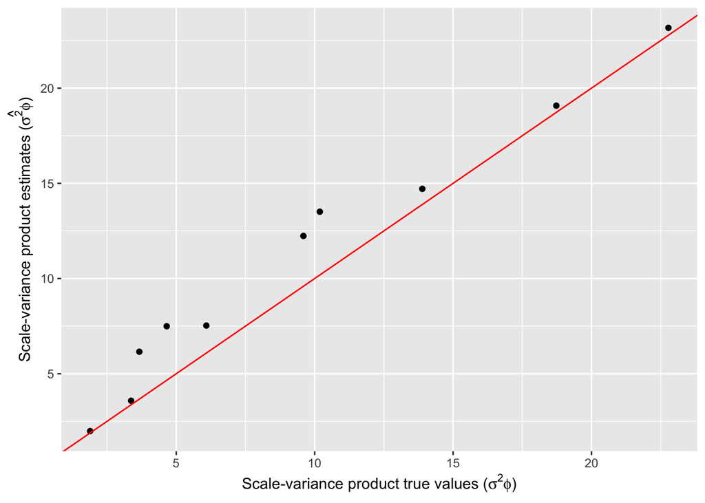

```r
ccc = 5 # cache_indicator
df=list(mcmc.store)
burnin=150
thin=2
N <- dim(df[[1]]$rhat)[1]
samples_after_burnin <- c(1:N)[-c(1:burnin)]
samples <- samples_after_burnin[seq(1, length(samples_after_burnin),by=thin)]

s2 <- 1
rhatmcmc <- mcmc.list(lapply(s2,function(x){mcmc(df[[x]]$rhat[samples,])}))
phihatmcmc <- lapply(s2,function(x){diag(df[[x]]$phihat)})
sigmahatmcmc <- lapply(s2,function(x){diag(df[[x]]$sigmahat)})
phisigmahatmcmc <- lapply(s2,function(x){diag(df[[x]]$phihat * df[[x]]$sigmahat)})
betahatmcmc <- lapply(s2,function(x){mcmc(df[[x]]$betahat)})
# test location prediction
ytestpredmcmc <- mcmc.list(lapply(s2,function(x){mcmc(simp.mat(df[[x]]$ytestpred[samples,,]))}))
ytestpredmcmc2 <- lapply(1:q, function(y){mcmc.list(lapply(s2,function(x){mcmc(df[[x]]$ytestpred[samples,y,])}))})
wmcmc <- mcmc.list(lapply(s2,function(x){mcmc(simp.mat(df[[x]]$w[samples,,]))}))

# cross-correlation estimates
rhat <- colMeans(as.matrix(rhatmcmc),na.rm = TRUE)
rhat_interv <- HPDinterval(rhatmcmc)[[1]]
rhat_lower <- rhat_interv[,1]
rhat_upper <- rhat_interv[,2]

# sigma_ij*phi_ij
true2 <- unlist(lapply(clqs_2,function(x){df[[1]]$sigma[x[1],x[2]] * df[[1]]$phi[x[1],x[2]]}))
rhatmcmcv2 <- unlist(lapply(1:length(clqs_2),function(u){
      v <- clqs_2[[u]]
      sqrt(sigmahatmcmc[[1]][v[1]] * sigmahatmcmc[[1]][v[2]]) * ((phihatmcmc[[1]][v[1]]^0.5) * (phihatmcmc[[1]][v[2]]^0.5)) * rhat[u]
    }))

rhatmcmcv2_lower <- unlist(lapply(1:length(clqs_2),function(u){
      v <- clqs_2[[u]]
      sqrt(sigmahatmcmc[[1]][v[1]] * sigmahatmcmc[[1]][v[2]]) * ((phihatmcmc[[1]][v[1]]^0.5) * (phihatmcmc[[1]][v[2]]^0.5)) * rhat_lower[u]
    }))


rhatmcmcv2_upper <- unlist(lapply(1:length(clqs_2),function(u){
      v <- clqs_2[[u]]
      sqrt(sigmahatmcmc[[1]][v[1]] * sigmahatmcmc[[1]][v[2]]) * ((phihatmcmc[[1]][v[1]]^0.5) * (phihatmcmc[[1]][v[2]]^0.5)) * rhat_upper[u]
    }))

# Scale* variance values
data.frame(true=diag(df[[1]]$sigma)*diag(df[[1]]$phi), est=phihatmcmc[[1]]*sigmahatmcmc[[1]]) %>% ggplot(aes(x=true,y=est)) + geom_point() + labs(y="True cross-correlation",x="Estimated cross-correlation") + geom_abline(slope = 1, intercept = 0,col="Red") + labs(y=expression(paste("Scale-variance product estimates (", hat(sigma^2*phi),")")), x= expression(paste("Scale-variance product true values (", sigma^2*phi,")")))
```

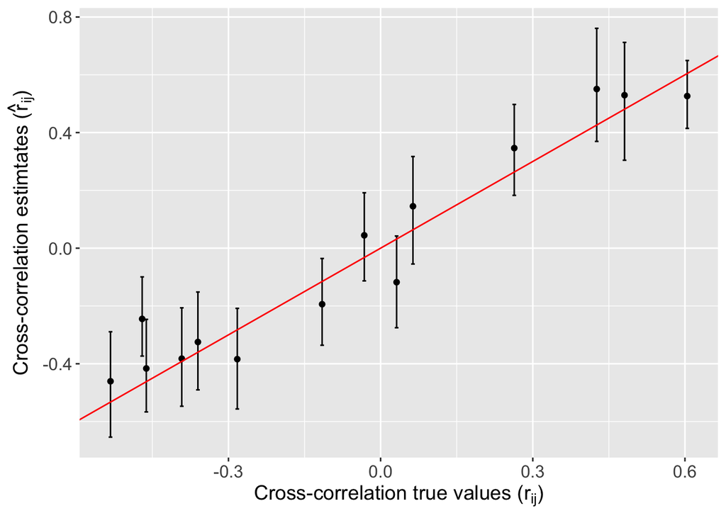

```r
# Plot true vs estimated scaled cross-correlation
data.frame(true=true, est=rhat) %>% ggplot(aes(x=true,y=est)) + geom_point() + geom_errorbar(aes(ymin=rhat_lower,ymax=rhat_upper)) +  labs(x=expression(paste("Cross-correlation true values (",r[ij],")")),y=expression(paste("Cross-correlation estimtates (",hat(r)[ij],")"))) + geom_abline(slope = 1, intercept = 0,col="Red") + theme(axis.text=element_text(size=12),axis.title=element_text(size=14,face="bold"))
```

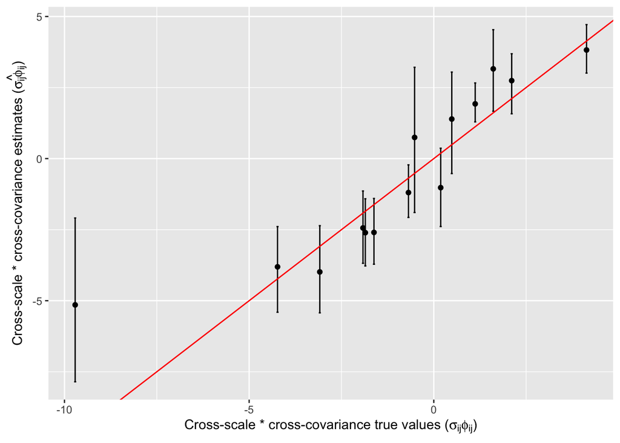

```r
# Plot true vs estimated sigma_ij*phi_ij
data.frame(true=true2, est=rhatmcmcv2, est_lower=rhatmcmcv2_lower, est_upper=rhatmcmcv2_upper) %>% ggplot(aes(x=true,y=est)) + geom_point() + geom_errorbar(aes(ymin = est_lower, ymax = est_upper)) + geom_abline(slope = 1, intercept = 0, col="Red") + labs(y=expression(paste("Cross-scale * cross-covariance estimates (", hat(sigma[ij]*phi[ij]),")")), x= expression(paste("Cross-scale * cross-covariance true values (", sigma[ij]*phi[ij],")")))
```

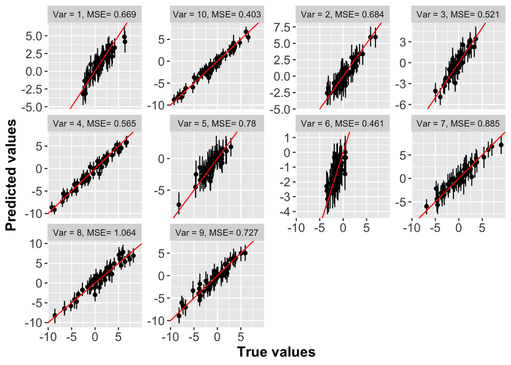

```r
# Plot true test data vs predictions
ypred = sapply(1:q, function(x){colMeans(ytestpredmcmc2[[x]][[1]],na.rm=TRUE)})
ypred_lower= sapply(1:q, function(x){HPDinterval(ytestpredmcmc2[[x]])[[1]][,1]})
ypred_upper= sapply(1:q, function(x){HPDinterval(ytestpredmcmc2[[x]])[[1]][,2]})


predvstrue= data.frame(true= as.numeric(mcmc.store$ytest), pred= as.numeric(ypred), pred_lower=as.numeric(ypred_lower), pred_upper=as.numeric(ypred_upper), var=rep(1:q, each=(n*test.prop)))
predmse= predvstrue %>% group_by(var) %>% summarize(mse=mean((true-pred)^2,na.rm=TRUE))
predvstrue= predvstrue %>% full_join(predmse) %>% mutate(var_mse=paste0("Var = ",var, ", MSE= ", round(mse,3)))
predvstrue %>% ggplot(aes(x=true,y=pred)) + geom_point() +
  geom_errorbar(aes(ymin=ypred_lower,ymax=ypred_upper)) +
  geom_abline(slope=1,intercept = 0, col="Red") + facet_wrap(~var_mse, scales='free_y') + labs(x="True values", y="Predicted values") +  theme(axis.text=element_text(size=12),axis.title=element_text(size=14,face="bold"))
```

Apanasovich, Tatiyana V, Marc G Genton, and Ying Sun. 2012. “A Valid Matérn Class of Cross-Covariance Functions for Multivariate Random Fields with Any Number of Components.” *Journal of the American Statistical Association* 107 (497): 180–93.

Banerjee, S., B. P. Carlin, and A. E. Gelfand. 2014. “Hierarchical Modeling and Analysis for Spatial Data.” In, Second. Boca Raton, FL: Chapman & Hall/CRC.

Cressie, Noel A. C., and Christopher K. Wikle. 2011. “Statistics for Spatio-Temporal Data.” In. Wiley Series in Probability and Statistics. Hoboken, NJ: Wiley. http://opac.inria.fr/record=b1133266.

Dey, Debangan, Abhirup Datta, and Sudipto Banerjee. 2021. “Graphical Gaussian Process Models for Highly Multivariate Spatial Data.” *Biometrika*, December. https://doi.org/10.1093/biomet/asab061.

Lauritzen, Steffen L. 1996. *Graphical Models*. Vol. 17. Clarendon Press.

Wackernagel, Hans. 2013. *Multivariate Geostatistics: An Introduction with Applications*. Springer Science & Business Media.